# Reproducible Research: Peer Assessment 1

## Loading and preprocessing the data

The following packages are used to produce this report:

```r
library(ggplot2)
library(knitr)
library(scales)
```

Read the dataset:

```r
activity <- read.csv(unz("activity.zip", filename = "activity.csv"), sep = ",",
    header = T)
activity$date <- as.Date(activity$date)
```

## What is mean total number of steps taken per day?

Question 1: Make a histogram of the total number of steps taken each day The following code can be used to generate the histogram:

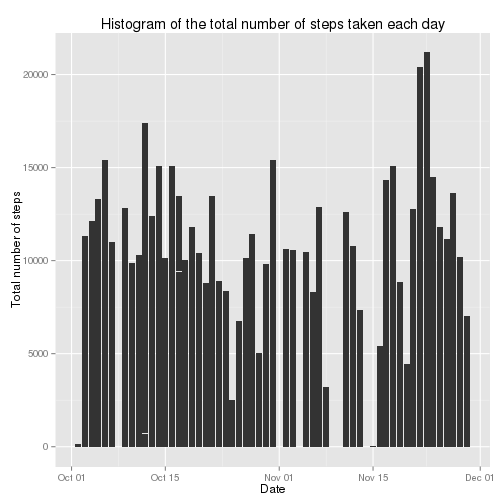

```r
ggplot(activity, aes(x = date, y = steps)) + geom_histogram(stat = "identity") +
    labs(title = "Histogram of the total number of steps taken each day", x = "Date",
        y = "Total number of steps")
```

Question 2: Calculate and report the *mean* and *median* total number of steps taken per day

The following code can be used to calculate the mean and median:

```r
activityWithoutNA <- na.omit(activity)
totalStepsPerDay <- aggregate(activityWithoutNA$steps, list(activityWithoutNA$date),
    sum)$x

mean(totalStepsPerDay)
```

```
## [1] 10766
```

```r
median(totalStepsPerDay)
```

```
## [1] 10765
```

## What is the average daily activity pattern?

Question 1: Make a time series plot (i.e. type = “l”) of the 5-minute interval (x-axis) and the average number of steps taken, averaged across all days (y-axis)

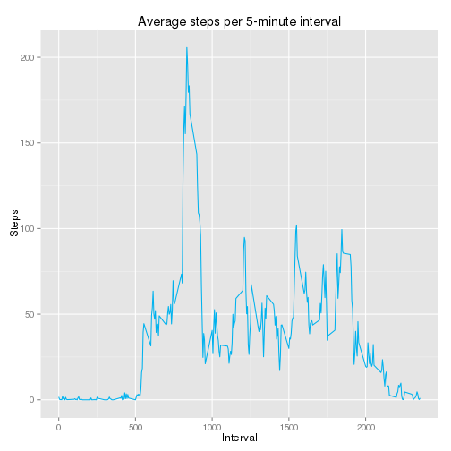

```r
meanStepsPerInterval <- aggregate(list(Steps = activity$steps), by = list(Interval = activity$interval),
    FUN = mean, na.rm = TRUE)

ggplot(meanStepsPerInterval, aes(x = Interval, y = Steps)) + geom_line(color = "deepskyblue2") +
    ggtitle("Average steps per 5-minute interval")
```

Question 2: Which 5-minute interval, on average across all the days in the dataset, contains the maximum number of steps?

```r
maxMeanPerInterval <- max(meanStepsPerInterval$Steps)
subset(meanStepsPerInterval, Steps == maxMeanPerInterval)$Interval
```

```
## [1] 835
```

## Imputing missing values

Question 1: Calculate and report the total number of missing values in the dataset (i.e. the total number of rows with NAs)

```r
sum(is.na(activity))
```

```
## [1] 2304
```

Question 2: Devise a strategy for filling in all of the missing values in the dataset. The strategy does not need to be sophisticated. For example, you could use the mean/median for that day, or the mean for that 5-minute interval, etc.

Question 3: Create a new dataset that is equal to the original dataset but with the missing data filled in.

```r
meanWithoutNA <- function(x) {
    mean(x, na.rm = TRUE)
}

mergedIntervalMeans <- merge(activity, meanStepsPerInterval, by.x = "interval",
    by.y = "Interval")

rowsWithNA = is.na(mergedIntervalMeans$steps)

mergedIntervalMeans[rowsWithNA, "steps"] <- mergedIntervalMeans[rowsWithNA,
    "Steps"]

activityNew <- mergedIntervalMeans[, c("steps", "date", "interval")]
```

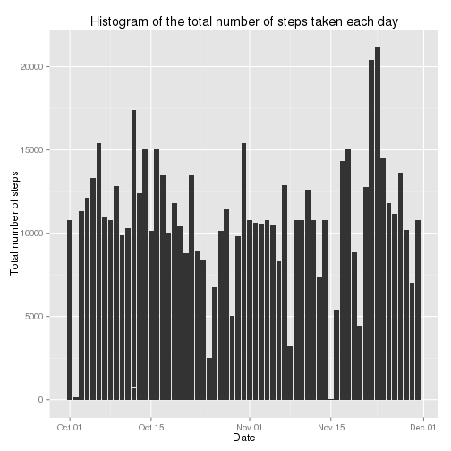

```r
ggplot(activityNew, aes(x = date, y = steps)) + geom_histogram(stat = "identity") +
    labs(title = "Histogram of the total number of steps taken each day", x = "Date",
        y = "Total number of steps")
```

## Are there differences in activity patterns between weekdays and weekends?

Question 1: Create a new factor variable in the dataset with two levels – “weekday” and “weekend” indicating whether a given date is a weekday or weekend day.

```r
activityWeekday <- weekdays(activityNew$date)
activityWeekend <- activityWeekday == "Sunday" | activityWeekday == "Saturday"
activityNew$weekday <- factor(activityWeekend, levels = c(FALSE, TRUE), labels = c("weekday",
    "weekend"))
```

Question 2: Make a panel plot containing a time series plot (i.e. type = “l”) of the 5-minute interval (x-axis) and the average number of steps taken, averaged across all weekday days or weekend days (y-axis).

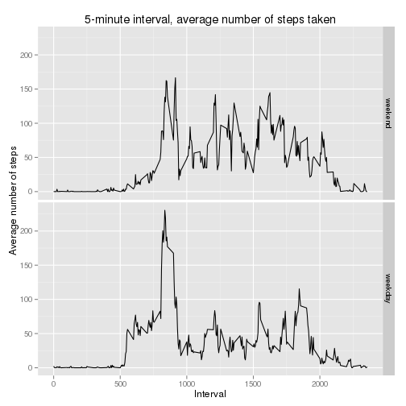

```r
averageStepsPerDay <- aggregate(activityNew$steps, list(Interval = as.numeric(as.character(activityNew$interval)),
    Weekday = activityNew$weekday), mean)

ggplot(averageStepsPerDay, aes(x = Interval, y = x)) + geom_line() + facet_grid(Weekday ~
    ., , as.table = FALSE) + labs(title = "5-minute interval, average number of steps taken",
    x = "Interval", y = "Average number of steps")
```